# [numpy](http://www.numpy.org/)

```python
import numpy as np
```

NumPy это open-source модуль для python, который предоставляет общие математические и числовые операции в виде пре-скомпилированных, быстрых функций. Они объединяются в высокоуровневые пакеты. Они обеспечивают функционал, который можно сравнить с функционалом MatLab. NumPy (Numeric Python) предоставляет базовые методы для манипуляции с большими массивами и матрицами. SciPy (Scientific Python) расширяет функционал numpy огромной коллекцией полезных алгоритмов, таких как минимизация, преобразование Фурье, регрессия, и другие прикладные математические техники.

## numpy arrays

Массивы бывают 1-мерные (вектора) 2-мерные (матрицы) и многомерные (условно тензоры).

Все элементы массива должны принадлежать к одному типу данных.

Создадим одномерный массив из списка при помощи функции `array`:

```python
np.array([1, 2, 3])
```

```
array([1, 2, 3])
```

Создадим двумерный массив из списка при помощи функции array. Обратите внимание на скобки.

```python
np.array([[1, 2, 3], [4, 5, 6], [7, 8, 9]])
```

```
array([[1, 2, 3],
       [4, 5, 6],
       [7, 8, 9]])
```

Но проще создавать массивы при помощи функции `arange`.

```python
np.arange(10, 101, 10)
```

```
array([ 10,  20,  30,  40,  50,  60,  70,  80,  90, 100])
```

Для создания специфических массивов надо использовать специальные методы. Нарпимер, `zeros` создаёт массив нулей.

```python
np.zeros(3)
```

```
array([0., 0., 0.])
```

А метод `ones` создаёт массив единиц.

```python
np.ones(3)
```

```
array([1., 1., 1.])
```

Для создания двуменых массивов необходимо передать функции кортеж, первый элемент которого обозначат количество строк, а второй — столбцов.

Для создания массива с необходимым количеством линейнораспределённых элементов из заданного промежутка используется функция `linspace`.

```python
np.linspace(10, 100, num=15)
```

```
array([ 10.        ,  16.42857143,  22.85714286,  29.28571429,
        35.71428571,  42.14285714,  48.57142857,  55.        ,
        61.42857143,  67.85714286,  74.28571429,  80.71428571,
        87.14285714,  93.57142857, 100.        ])
```

Для создания единично матрицы используется функция `eye`. Ей можно задавать смещение.

```python
np.eye(5, k=2)
```

```
array([[0., 0., 1., 0., 0.],
       [0., 0., 0., 1., 0.],
       [0., 0., 0., 0., 1.],
       [0., 0., 0., 0., 0.],
       [0., 0., 0., 0., 0.]])
```

## Массивы случайных чисел

Можно создавать массивы со случайными числами при помощи функции rand() модуля random.

```python
np.random.rand(4)
```

```
array([0.26437504, 0.94408227, 0.04647417, 0.70050205])
```

Для получения случайных чисел из нормального распределения используем функцию randn() из модуля random. Для создания матрицы случайных чисел надо передать функции два числа, не кортеж

```python
np.random.randn(5)
```

```
array([ 0.45133976, -1.59993226,  1.03351685,  0.56488102,  0.91875806])
```

с равномерным распределением всё похоже

```python
np.random.uniform(10, 100, (3, 3))
```

```
array([[88.60061463, 20.51125522, 29.51395969],
       [29.03225571, 79.52490546, 71.89740721],
       [89.91924457, 46.51368169, 24.74561669]])
```

```python
np.random.randint(2, 100)
```

```
35
```

## Атрибуты и методы массивов

Попробуем узнавать различную информацию о массивах и производить манипуляции с ними при помощи свойств и методов массивов.

```python
arr = np.arange(25)
```

Размерность массива можно узнать при помощи функции свойства shape.

```python
arr.shape
```

```
(25,)
```

Свойство dtype возващяет тип переменной.

```python
arr.dtype
```

```
dtype('int64')
```

```python
matrix = arr.reshape(5, 5)
matrix
```

```
array([[ 0,  1,  2,  3,  4],
       [ 5,  6,  7,  8,  9],
       [10, 11, 12, 13, 14],
       [15, 16, 17, 18, 19],
       [20, 21, 22, 23, 24]])
```

Также можно находить максимум и минимум при помощи методов max, min, argmax, argmin, счиатать средние значения, стандартные отклонения и многое другое.

```python
arr.std()
```

```
7.211102550927978
```

## Индексация массивов

```python
arr
```

```
array([ 0,  1,  2,  3,  4,  5,  6,  7,  8,  9, 10, 11, 12, 13, 14, 15, 16,
       17, 18, 19, 20, 21, 22, 23, 24])
```

В базовом виде работает как в обычном Питоне.

```python
arr[0:11:2]
```

```
array([ 0,  2,  4,  6,  8, 10])
```

Для срайсам по различным измерениям многомерных массивов указываем их через запятую

```python
matrix[1:4, :]
```

```
array([[ 5,  6,  7,  8,  9],
       [10, 11, 12, 13, 14],
       [15, 16, 17, 18, 19]])
```

## Броадкастинг

```python
arr*3
```

```
array([ 0,  3,  6,  9, 12, 15, 18, 21, 24, 27, 30, 33, 36, 39, 42, 45, 48,
       51, 54, 57, 60, 63, 66, 69, 72])
```

Но будьте осторожны — тут мы всего лишь создаём ссылки на элементы массива arr с 0 по 5:

```python
a = arr[:5]
```

```python
a[:] = 9
```

```python
arr
```

```
array([ 9,  9,  9,  9,  9,  5,  6,  7,  8,  9, 10, 11, 12, 13, 14, 15, 16,
       17, 18, 19, 20, 21, 22, 23, 24])
```

## Выбор по условию

```python
arr < 10
```

```
array([ True,  True,  True,  True,  True,  True,  True,  True,  True,
        True, False, False, False, False, False, False, False, False,
       False, False, False, False, False, False, False])
```

```python
arr[arr < 10]
```

```
array([9, 9, 9, 9, 9, 5, 6, 7, 8, 9])
```

## Базовые операции в numpy

+, -, *, /, **, sqrt, exp, sin, log, max, mix, mean и др.: https://docs.scipy.org/doc/numpy-1.13.0/reference/ufuncs.html

Для большинства операций можно указывать ось, по которой она будет производиться:

```python
matrix.sum()
```

```
335
```

```python
matrix.sum(axis=0) # сумма по столбцам
```

```
array([59, 63, 67, 71, 75])
```

Кстати говоря, на 0 делить разрешено

```python
2/0
```

```
---------------------------------------------------------------------------
ZeroDivisionError                         Traceback (most recent call last)
<ipython-input-163-e8326a161779> in <module>()
----> 1 2/0

ZeroDivisionError: division by zero
```

```python
np.array([-1, 2, 3]) / np.array([0, 2, 3])
```

```
array([-inf,   1.,   1.])
```

## Практическое задание

Создайте массив класса np.ndarray ширины 4 и высоты 3 с двойками на главной диагонали и единицами на первой диагонали над главной, т.е. воплощение матрицы

```
array([[2., 1., 0., 0.],
       [0., 2., 1., 0.],
       [0., 0., 2., 1.]])
```

## Практическое задание

Создайте матрицу чисел от 1 до 25 размерностью 5×5

```
array([[ 1,  2,  3,  4,  5],
       [ 6,  7,  8,  9, 10],
       [11, 12, 13, 14, 15],
       [16, 17, 18, 19, 20],
       [21, 22, 23, 24, 25]])
```

Обрежьте её следующим образом:

```python
mat[2: , 2:]
```

```
array([[13, 14, 15],
       [18, 19, 20],
       [23, 24, 25]])
```

## Практическое задание

Напишите функцию `decorate_matrix`, которая получает на вход одно целое число больше единицы. Функция должна возвращать матрицу `n` на `n`, у которой на границах стоят единицы, а на всех остальных позициях(если остались позиции не на границах) стоят нули.

```python
# ожидаемый резальтат для аргумента 5
```

```
array([[1., 1., 1., 1., 1.],
       [1., 0., 0., 0., 1.],
       [1., 0., 0., 0., 1.],
       [1., 0., 0., 0., 1.],
       [1., 1., 1., 1., 1.]])
```

# Обработка изображений

```python
import numpy as np
import matplotlib.pylab as plt

%matplotlib inline
```

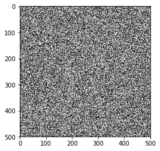

```python
import numpy as np
from matplotlib import pyplot as plt

random_image = np.random.random([500, 500])

plt.imshow(random_image, cmap='gray', interpolation='nearest');
```

```python
import requests


with open("lenna.png", "wb") as img_f:
    img_f.write(requests.get("https://i.stack.imgur.com/nL4u3.png").content)

im = plt.imread("lenna.png")
im.shape
```

```
(220, 220, 4)
```

[figure not shown]

```python
def plti(im, h=6, **kwargs):
    """
    Helper function to plot an image.
    """
    y = im.shape[0]
    x = im.shape[1]
    w = (y/x) * h
    plt.figure(figsize=(w,h))
    plt.imshow(im, interpolation="nearest", **kwargs)
    plt.axis('off')

plti(im)
```

Удалим прозрачность

```python
im = im[:,:,:3]
```

Обрежьте изображение до плеча

Получите негатив изображения

[figure not shown]

Сделайте изображение чёрно-белым. Для вывода изображения передайте в функцию аргумент `plti` `cmap='gist_gray'`.

[figure not shown]

Поместите жёлтый квадрат 100×100px в верхнем левом углу

[figure not shown]

## Добавьте случайный шум в изображение

[figure not shown]

```
Clipping input data to the valid range for imshow with RGB data ([0..1] for floats or [0..255] for integers).
```

[figure not shown]

# Для самостоятельного изучения

- [Python for data science : Part 2 на towardsdatascience.com](https://towardsdatascience.com/python-for-data-science-part-2-373d6473fa40)
- [Цикл статей «NumPy в Python» на Хабре](https://habr.com/post/352678/)